# DM - Master Big Data - Régression non-paramétrique

Jeremy BRON

08 janvier 2018

# 1 - Exploration des propriétés de $g(x)$

## 1.1

Visualisation des données de X à l’aide d’un histogramme

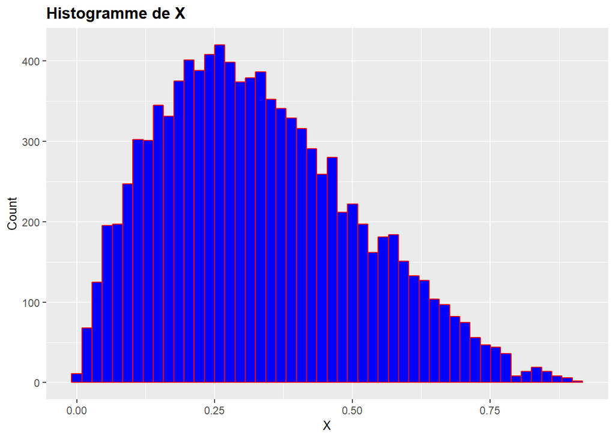

La distribution des X est centrée et biaisée vers la droite. La figure suivante représente la densité estimée à partir de la fonction R pour la comparer à une approche par noyaux de la fonction bkde avec plusieurs paramètres h.

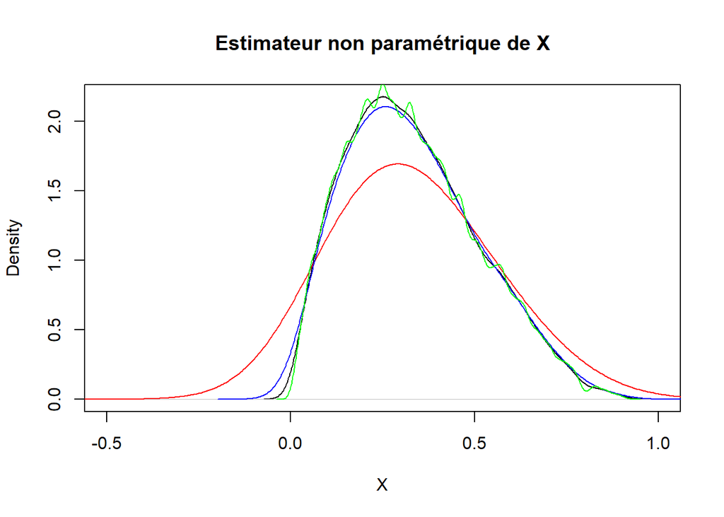

- Si h est trop grand (h = 0,15 en rouge), l’estimateur est très régulier, mais biaisé, plus h est grand pour la densité estimée est plate.
- Si h est trop petit (h= 0,01 en vert), l’estimateur est oscillant (grande variance), mais avec un faible biais. On voit bien que la courbe verte oscille autour de la densité estimée par R en noir.
- Quand la valeur d’h se rapproche de la valeur optimale (h = 0.05 en bleu), la courbe se rapproche de la densité des données, sans osciller.

## 1.2

Au vu des plots d’estimateurs précédents, on réduit la fenêtre de recherche de h à [0.01,0.05].

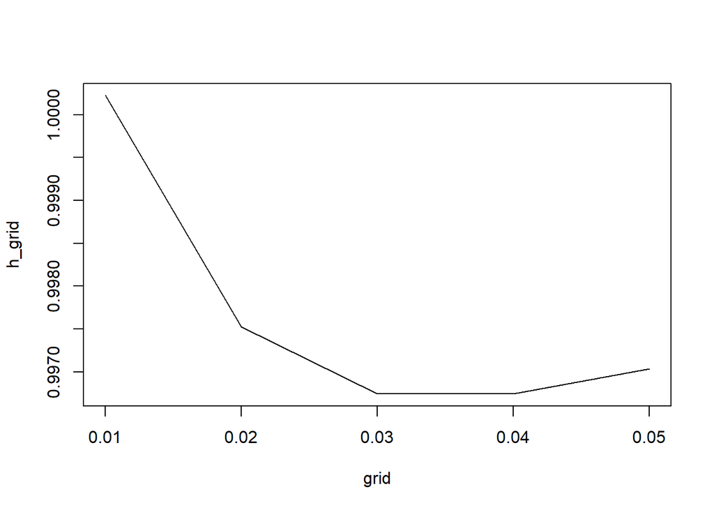

```r
#fonction du cours
grid=seq(0.01,0.05,length=5)
# h_grid=CVbwt(grid,d$X,d$Y)
plot(grid,h_grid,type="l")
```

```r
#package sm
h.select(d$X)
```

```
## [1] 0.02994713
```

- Graphiquement, la valeur de h optimale se situe environ entre 0.03 et 0.04.
- Le package sm propose une fonction pour calculer directement le h optimal: h = 0.02994713

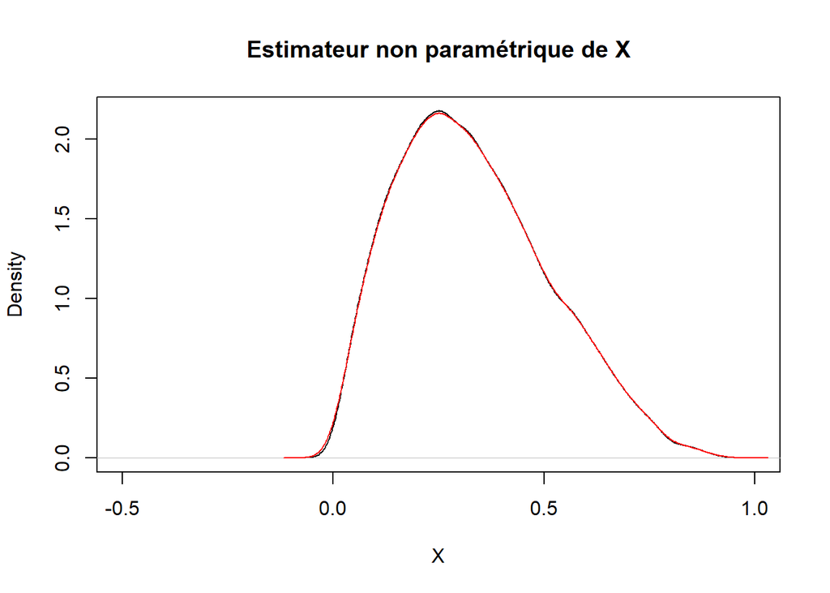

La densité avec ce paramètre h est très similaire avec celle estimée par la fonction densité de R sur les données. On estime donc bien la densité avec ce paramètre.

## 1.3

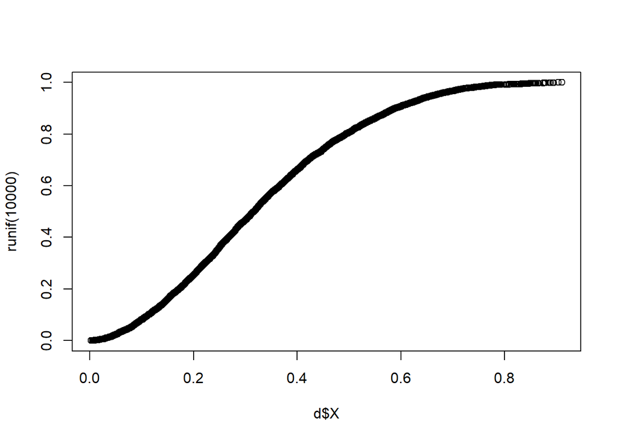

# 2 - Reconstruction de $r(x)$

## 2.1

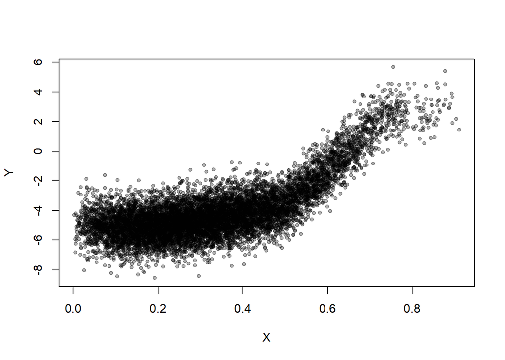

```r
plot(d, col=rgb(0,0,0,alpha=0.3) , pch = 20)
```

La représentation des données laisse pensé que r est linéaire par morceaux et non simplement linéaire: * Pour X entre 0 et 0.5 la pente est faible * Pour X entre 0.5 et 0.8 : la pente est plus forte que pour l’intervalle précédent * Pour X supérieurs à 0.8 : la pente est faible, voire nulle.

L’estimation non paramétrique de r par des polynômes locaux, avec ici par exemple de polynômes d’ordre 1 (linéaires), serait donc une première étape nécessaire pour implémenter un modèle linéaire par morceaux.

## 2.2

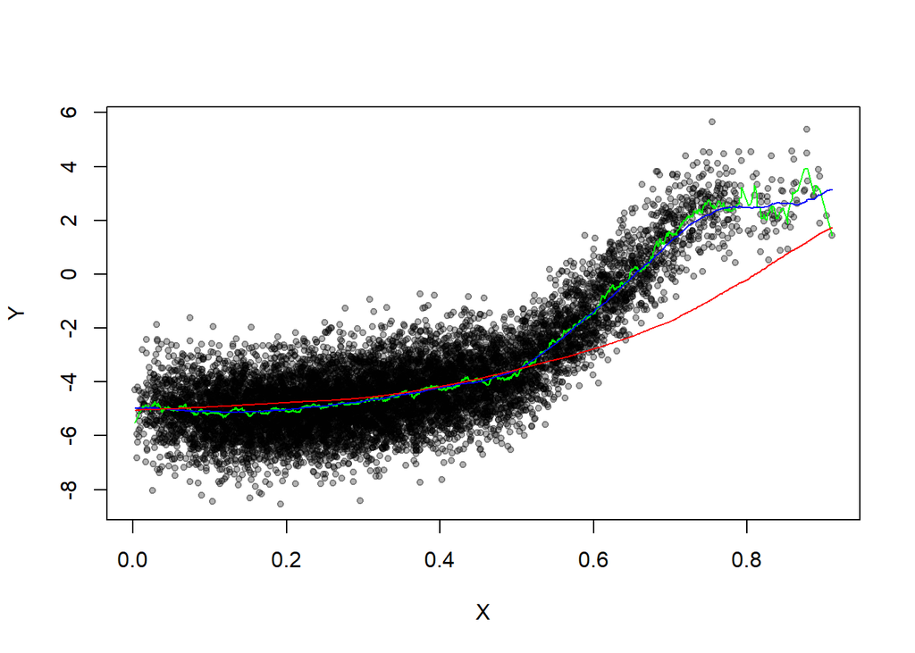

```r
resQ2.a = ksmooth(d$X,d$Y,bandwidth=0.5,x.points=d$X)
resQ2.b = ksmooth(d$X,d$Y,bandwidth=0.1,x.points=d$X)
resQ2.c = ksmooth(d$X,d$Y,bandwidth=0.01,x.points=d$X)
plot(d, col=rgb(0,0,0,alpha=0.3) , pch = 20)
lines(resQ2.c$x,resQ2.c$y, col ="green")
lines(resQ2.b$x,resQ2.b$y, col ="blue")
lines(resQ2.a$x,resQ2.a$y, col ="red")
```

- Pour h = 0.5 : h est trop grand la densité estimée est ne prends pas en compte le changement de pente pour X > 0.5. La courbe est aplatie.
- Pour h = 0.1 : h est plutôt adapté, l’estimation prend en comptes la tendance des données sans se mettre à osciller
- Pour h = 0.01 : h est trop petit, l’estimation oscille légèrement entre 0 et 0.7; entre 0.7 et 1 : le jeu de donnée contient moins de points et l’estimation oscille plus fortement.

## 2.3.A

```r
# (a) - Directement avec le package SM
h.select(d$X,d$Y, method = "cv")
```

```
## [1] 0.01491244
```

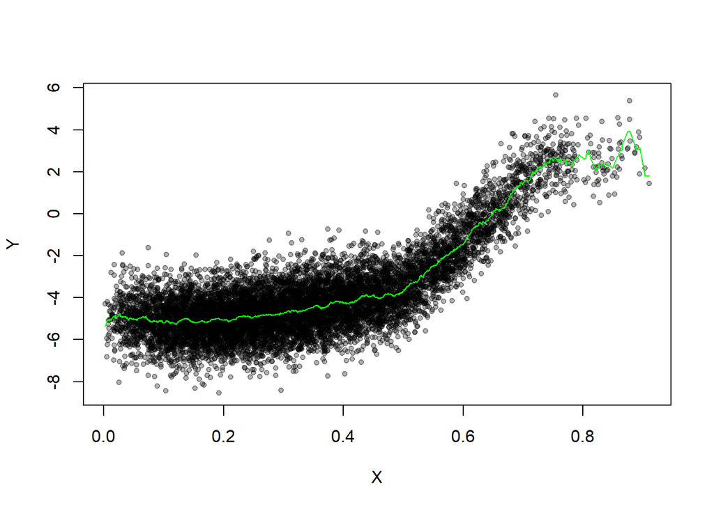

```r
resQ2.3 = ksmooth(d$X,d$Y,bandwidth=0.01491244,x.points=d$X)
plot(d, col=rgb(0,0,0,alpha=0.3) , pch = 20)
lines(resQ2.3$x,resQ2.3$y, col ="green")
```

- Dans le cas d’un h unique pour toutes les données la valeur de h est légèrement trop petite, cela provoque des oscillations mineures entre 0 et 0.7 et de plus fortes oscillations entre 0.7 et 1.

## 2.3.B

Avec la fonction spill sur des blocs locaux et la fonction du cours, on recherche le h local pour 5 blocs

```r
h_CVloc(d$X,d$Y,5)$h_loc
```

```
## [1] 0.01999569 0.02791891 0.02650007 0.02945790 0.03049580
```

À première vue, cela permet de sélectionner des h plus grands, surtout quand X augmente: là où il y a moins de données (donc plus de variance pour h trop petit)

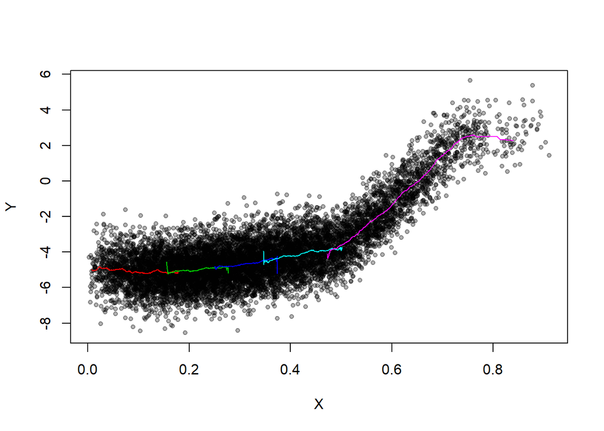

```r
#découpage des données en blocks contenant le même nombre de points
block = 5
resQ23b =list()
X_sort=sort(d$X)
Y_sort=d$Y[order(d$X)]
#calcul des estimateur sur chaques blocks
for (i in 0:(block-1)) {
  n = NROW(d)/block
  resQ23b[[i+1]] = ksmooth(X_sort[(1+n*i):(n*(1+i))],
                           Y_sort[(1+n*i):(n*(1+i))],
                           bandwidth=hlock$h_loc[i+1],
                           x.points=d$X[(1+n*i):(n*(1+i))])
}

plot(d, col=rgb(0,0,0,alpha=0.3) , pch = 20)
for (i in 1:5) {
  lines(resQ23b[[i]]$x,resQ23b[[i]]$y, col =i+1)
}
```

Les estimations débordent entre elles aux bornes des blocs, on filtre les données pour garder seulement les valeurs de l’estimateur dont les X sont compris dans les blocs.

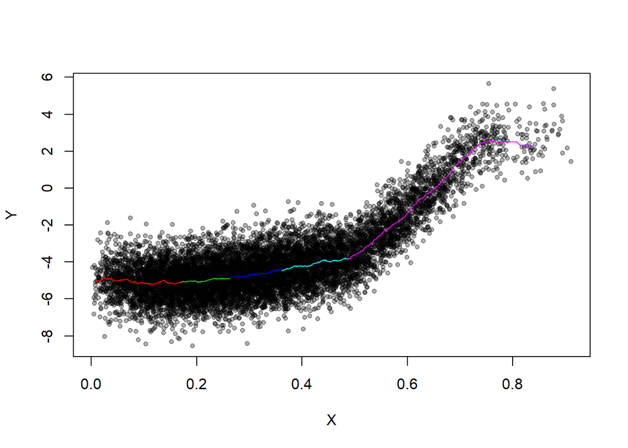

```r
plot(d, col=rgb(0,0,0,alpha=0.3) , pch = 20)

for (i in 0:(block-1)) {
  resfilter = as.data.frame(resQ23b[[i+1]]) %>%
    filter(x <= max(X_sort[(1+n*i):(n*(1+i))])) %>%
    filter(x >= min(X_sort[(1+n*i):(n*(1+i))]))

  lines(resfilter$x,resfilter$y, col =i+2)}
```

Tous les blocs contiennent le même nombre de points. Le h local permet de mieux adapter la fenêtre aux données et limite les oscillations qui paraissent avec le h unique précédent. On remarque aussi que ma distribution des X n’est pas uniforme avec le 5eme bloc (en violet) s’étends sur les C de 0.5 à 1.

Remarque : On aurait pu découper les données plus intelligemment, non pas en blocs avec le même nombre de points mais selon les variations de la pente estimée de Y

Globalement on préférera un choix local mieux adapté aux données ici.

# 3 - Étude de la loi des $\xi i$

## 3.1

```r
# on pose N = n-1
U_n = function(Y,N){
    sum((Y[2:(N+1)]-Y[1:N])**2)/(2*(N-1))
  }

V_n = function(X,Y,N){
  X_sort=sort(X)
  Y_sort=Y[order(X)]
  sum((Y_sort[2:(N+1)]-Y_sort[1:N])**2)/(2*(N-1))
}

U_n(d$Y,9999)
```

```
## [1] 3.913744
```

```r
V_n(d$X,d$Y,9999)
```

```
## [1] 1.005775
```

## 3.2

```r
var(d$Y)
```

```
## [1] 3.918838
```

## 3.3

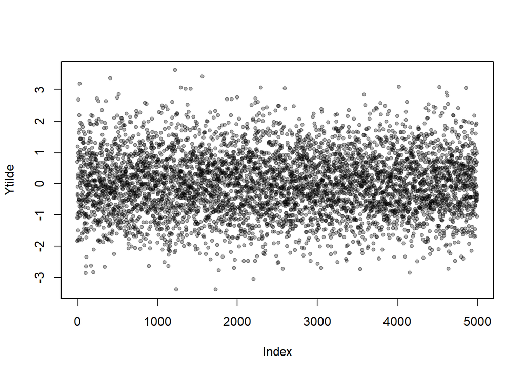

```r
X_sort=sort(d$X)
Y_sort=d$Y[order(d$X)]
hlock2 = h_CVloc(d$X,d$Y,2)
resQ33b = ksmooth(X_sort[5001:10000],Y_sort[5001:10000],bandwidth=hlock2$h_loc[2],x.points=X_sort[5001:10000])
Ytilde = Y_sort[5001:10000] - resQ33b$y
plot(Ytilde ,col=rgb(0,0,0,alpha=0.3) , pch = 20)
```

```r
mean(Ytilde)
```

```
## [1] 0.002111904
```

```r
var(Ytilde)
```

```
## [1] 1.010138
```

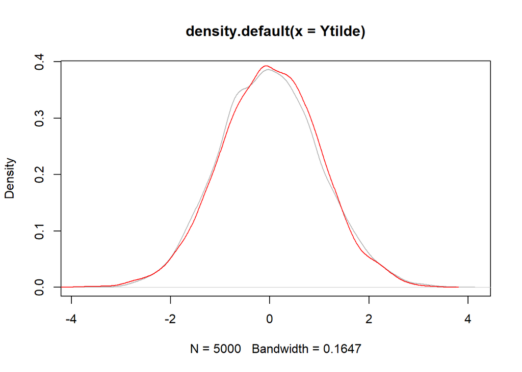

```r
plot(density(Ytilde) ,col=rgb(0,0,0,alpha=0.3) , pch = 20)
lines(density(rnorm(5000)), col = "red")
```

la densité des $\widetilde{Y}$ ressemble fortement à une loi normale (0,1).

## 3.4

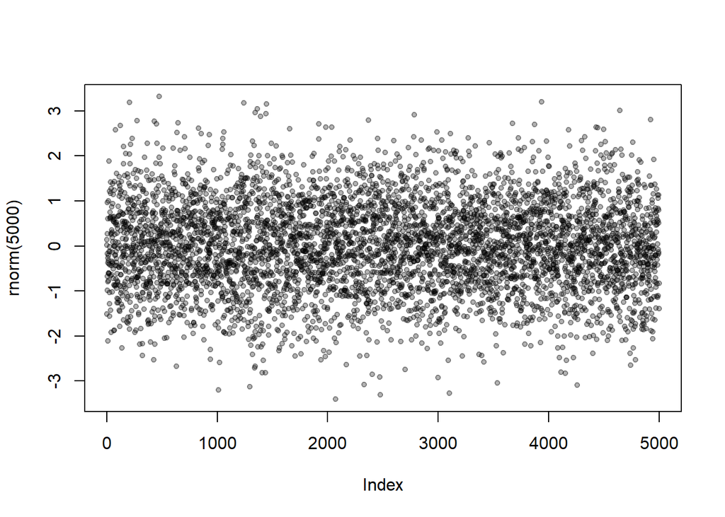

```r
plot(rnorm(5000),col=rgb(0,0,0,alpha=0.3) , pch = 20)
```

## 3.5

```r
shapiro.test(Ytilde)
```

```
##
##  Shapiro-Wilk normality test
##
## data:  Ytilde
## W = 0.99906, p-value = 0.006946
```

```r
#Test d'Anderson-Darling
ad.test(Ytilde)
```

```
##
##  Anderson-Darling test of goodness-of-fit
##  Null hypothesis: uniform distribution
##
## data:  Ytilde
## An = Inf, p-value = 1.2e-07
```

```r
#TCramer-von Mises test
cvm.test(Ytilde, "pnorm", mean=0, sd=1)
```

```
##
##  Cramer-von Mises test of goodness-of-fit
##  Null hypothesis: Normal distribution
##  with parameters mean = 0, sd = 1
##
## data:  Ytilde
## omega2 = 0.15511, p-value = 0.3744
```

On peut vérifier à l’aide d’un QQplot

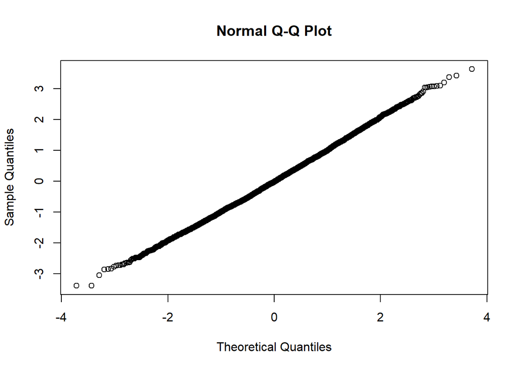